# R Notebook

# 1 Exploratory Data Analysis

It is easy to say the wrong things with data. Our explanations depend on our assumptions and our assumptions can be wrong.

As early as possible in the data life cycle it is important to look at the data, it’s biases and what is missing. We need to explore.

# 2 LOAD Data

Firstly, we need to load in the data.

The R language can import and export data in many formats. Here we load in data from an R native format and also CSV file.

```r
file.jobs <- "../../DATA/MonsterBoard-2013-n=20000.Rdata"
file.kwic <- "../../DATA/KWIC.csv"
df.KWIC <- read.csv(file.kwic, sep=";", comment.char="#")

# Search for help on function
?read.csv
?load

load(file.jobs)

# What is the type of the object we just loaded
class(df.KWIC)
```

```
[1] "data.frame"
```

```r
# What are the names used for the dimensions
names(df.KWIC)
```

```
[1] "JobText"    "Percentage"
```

```r
names(sample)
```

```
 [1] "PositionAdID"     "PositionID"       "JobTitle"         "City"             "PostalCode"       "SalaryTypeID"     "SalaryFrom"
 [8] "SalaryTo"         "CareerLevelID"    "EducationLevelID" "DateActive"       "DateExpires"      "JobAttributeIDs"  "JobCategoryIDs"
[15] "OccupationIDs"    "IndustryIDs"      "Keywords"         "JobBody"
```

# 3 All data is dirty

In this section we show that the city information has missing data. The typist of the data has used both upper and lower case.

> Assume that your data is dirty and that you have to find where

```r
attach(sample)
# Create a cross tabulation as a data.frame
city.list <- as.data.frame(table(City))
# Order the cross tabulation
city.list <- city.list[order(city.list$Freq, decreasing=TRUE),]
# Look at the first ten entries
head(city.list,n=10)
```

|  | City | Freq |
| --- | --- | --- |
| 716 | London | 4110 |
| 286 | City of London | 713 |
| 784 | Manchester | 614 |
| 116 | Birmingham | 461 |
| 675 | Leeds | 413 |
| 216 | Cambridge | 321 |
| 170 | Bristol | 313 |
| 1 |  | 308 |
| 988 | Reading | 257 |
| 1064 | Sheffield | 206 |

The word London has been written a number of times in slightly different upper and lower case formats.

```r
# Look at the different ways London is written. Typical input error.
?tolower
city.list[tolower(city.list$City) == "london",]
```

|  | City | Freq |
| --- | --- | --- |
| 716 | London | 4110 |
| 714 | london | 99 |
| 717 | LONDON | 57 |
| 715 | lONDON | 10 |

OK, let’s clean up and plot again by changing all words to lowercase.

```r
City <- tolower(City)
City[City==""] <- "Unknown"
City[City=="city"] <- "Unknown"
city.list <- as.data.frame(table(City))
city.list <- city.list[order(city.list$Freq, decreasing=TRUE),]
head(city.list,n=20)
```

|  | City | Freq |
| --- | --- | --- |
| 632 | london | 4276 |
| 249 | city of london | 719 |
| 693 | manchester | 628 |
| 106 | birmingham | 470 |
| 1125 | Unknown | 448 |
| 600 | leeds | 425 |
| 192 | cambridge | 323 |
| 152 | bristol | 322 |
| 869 | reading | 259 |
| 938 | sheffield | 211 |

[output cut: 10 more lines]

# 4 Visualise

Now we visualize. In this case we are plotting the top 20 cities listed against their frequency.

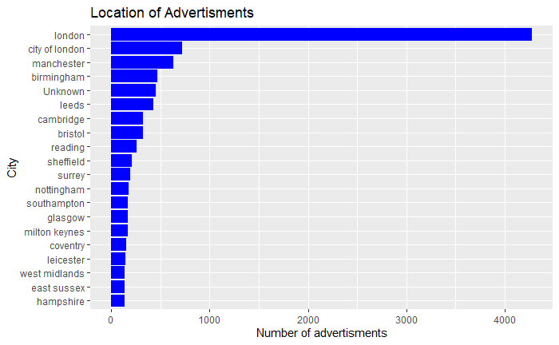

```r
library(ggplot2)

# select the first 20 entries
top <- 20
city.list.20 <- head(city.list, n=top)
# Now use GGPLOT2 to create a nice looking chart
# There are plenty examples on the Internet. Well worth experimenting
plt.city <- ggplot(city.list.20, aes(x=reorder(City,Freq),y=Freq)) +
    geom_bar(fill="blue",stat="identity") +
    coord_flip() +
    xlab("City") + ylab("Number of advertisments") +
    ggtitle("Location of Advertisments")

plt.city
```

With minor effort we can create a look and a feel using different themes from the `ggthemes` library

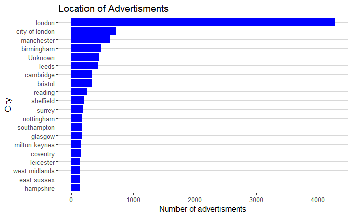

```r
library(ggthemes)
plt.city + theme_hc()
```

# 5 Postal Codes

Postal codes turn out to be particularly dirty so we clean up.

The implication for this data source is that we have to make assumptions about the randomness of postal codes, making any study weaker.

> Missing data is a typical issue when dealing with raw data

Do not make assumptions abour the quality of data. Visualize distributions where you can.

```r
head(PostalCode)
```

```
[1] "NULL"    "SG191RZ" "NULL"    "NULL"    "NULL"    "NULL"
```

```r
PostalCode[PostalCode=="NULL"] <- NA
head(PostalCode)
```

```
[1] NA        "SG191RZ" NA        NA        NA        NA
```

```r
# Measure the number of characters in an entry
?nchar
max(nchar(PostalCode, keepNA=FALSE))
```

```
[1] 8
```

```r
min(nchar(PostalCode, keepNA=FALSE))
```

```
[1] 0
```

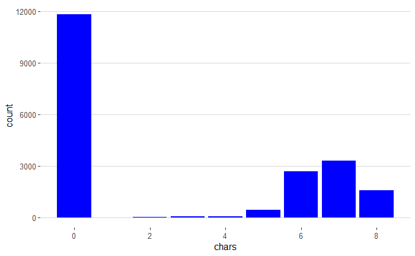

```r
df.chars <- data.frame(chars =nchar(PostalCode, keepNA=FALSE))
ggplot(df.chars, aes(x=chars)) + geom_bar(fill="blue") + theme_hc()
```

```r
# What is the percentage of entries that have a well formed postcode?
sum(df.chars$chars==6)/nrow(df.chars)
```

```
[1] 0.1337
```

# 6 Handling dates

Handling dates can be difficult. However, with the [`lubridate`](https://lubridate.tidyverse.org/) package we can minimize our effort.

You need to tell R that you are working on a DATE object by converting strings into a DATE.

> Bias in vacancy data can include job releases on a particular day of the week

```r
# We are looking at strings
class(DateActive)
```

```
[1] "character"
```

```r
DateActive <- as.Date(DateActive)
# Now the entries are treated as dates
class(DateActive)
```

```
[1] "Date"
```

```r
# Let's make our lives easier
sp(library(lubridate))
# ?wday
# Let's look at the first entry to show how things work
wday(DateActive[1], label=TRUE)
```

```
[1] Mon
Levels: Sun < Mon < Tue < Wed < Thu < Fri < Sat
```

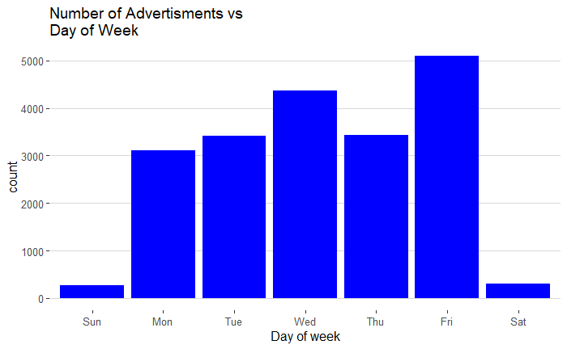

```r
# Let's create a new dimension named WDAY with the day of the week of the DATE assigned
sample$WDAY <- wday(DateActive, label=TRUE)

# Visualize where you can.
ggplot(sample,aes(x=WDAY)) +
    geom_bar(fill="blue") + theme_hc() +
    xlab("Day of week") + ggtitle("Number of Advertisments vs\nDay of Week")
```

> Keep asking yourself, where is the bias in the data.

# 7 Automated Report

There are even cheats with quickly scanning the data, for example using the [`datexplorer`](https://boxuancui.github.io/DataExplorer/) package

```r
#https://boxuancui.github.io/DataExplorer/
sp(library(DataExplorer))

# Output an introduction to the dataset city.list
introduce(city.list)
```

| rows | columns | discrete_columns | continuous_columns | all_missing_columns | total_missing_values | complete_rows | total_observations | memory_usage |
| --- | --- | --- | --- | --- | --- | --- | --- | --- |
| 1251 | 2 | 1 | 1 | 0 | 0 | 1251 | 2502 | 103160 |

```r
# Turn NA (Not available, no data) to the text Unknown
city.list[city.list == "Unknown"] <- NA
# Look at the impact on the introduction
introduce(city.list)
```

| rows | columns | discrete_columns | continuous_columns | all_missing_columns | total_missing_values | complete_rows | total_observations | memory_usage |
| --- | --- | --- | --- | --- | --- | --- | --- | --- |
| 1251 | 2 | 1 | 1 | 0 | 1 | 1250 | 2502 | 103160 |

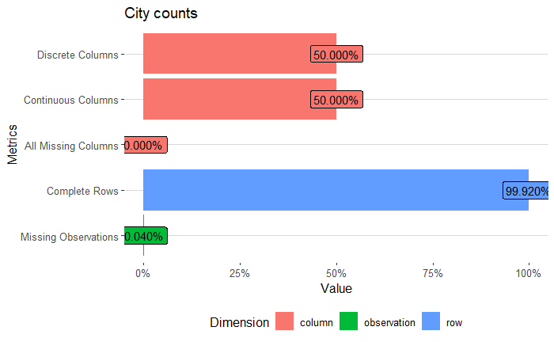

```r
# Make a nice report
plot_intro(city.list, ggtheme = theme_hc(),
             title = "City counts")
```

```r
# Now for something more complex
introduce(sample)
```

| rows | columns | discrete_columns | continuous_columns | all_missing_columns | total_missing_values | complete_rows | total_observations | memory_usage |
| --- | --- | --- | --- | --- | --- | --- | --- | --- |
| 20000 | 19 | 17 | 2 | 0 | 0 | 20000 | 380000 | 42643904 |

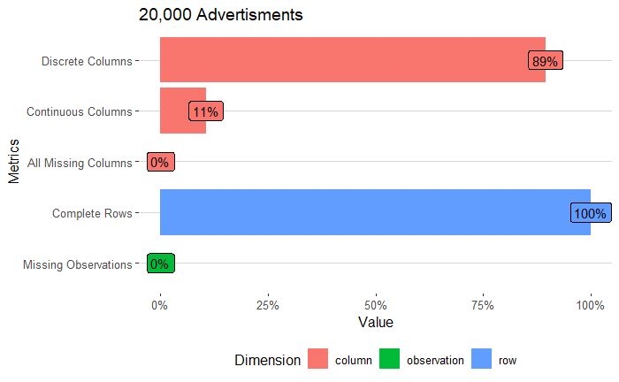

```r
plot_intro(sample, ggtheme = theme_hc(),
             title = "20,000 Advertisments")
```

```
11 columns ignored with more than 50 categories.
JobTitle: 13339 categories
City: 1419 categories
PostalCode: 3817 categories
SalaryFrom: 670 categories
SalaryTo: 729 categories
DateActive: 18428 categories
DateExpires: 17449 categories
OccupationIDs: 1538 categories
IndustryIDs: 1198 categories
Keywords: 1676 categories
JobBody: 17036 categories
```

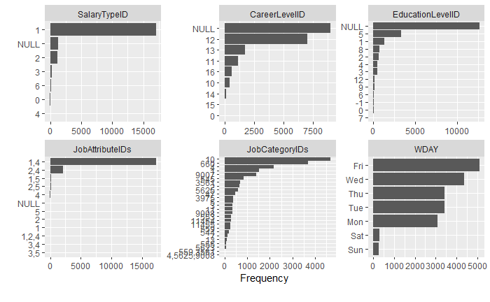

```r
plot_bar(sample)
```

```r
# Consider creating a full report
?create_report
#create_report(sample, report_title = "20,000 Advertisements", output_file="eda-report-sample.html")
```

# 8 Save Data

It is straight forward to save data in one format to another within R. Here we convert the data originally in CSV format to a compressed R format.

```r
# You may need to Change the location of data file
file.kwic.Rdata <- "../../DATA/KWIC.Rdata"
# Notice Significantly compressed
save(df.KWIC, file = file.kwic.Rdata, compress=TRUE)
```

# 9 Look at the first job advertisment

Finally we can look at specific job advertisments.

```r
sample$JobBody[1]
```

```
[1] "Job Description: New Business Development Manager  Sector: Retail Overview: An experienced new business development candidate is required to win and close contracts in the UK market. In this role the candidate will be required to drive the professional services into Retail companies.  The candi…
```

# 10 Package Versions